# Buffered Pekel data vs gage data

Here we use stream gage height data to fill gaps in the coincident Pekel JRC Global Surface Water timeseries. Monthly data are used in both cases, limited to HUC 18020116. Pekel data are restricted to a 500-m buffer around each stream.

**Maximum monthly water extent - Pekel data**

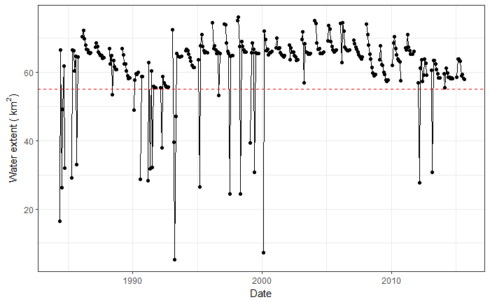

There’s a lot of drop-out data in the time series, so the data need to be cleaned up first.

**Cleaned-up plot**

The result is better, though some spurious values are still apparent. One question is how much to clean those up prior to subsequent processing.

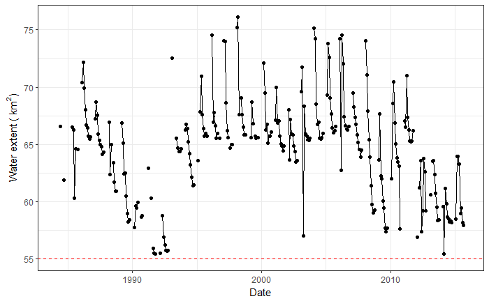

**Stream gage data**

Directly query NWIS for monthly stream gage data after filtering for HUC and time constraints (data through at least 2000).

Of the 10 gages that satisfy the location and temporal requirements, only 1 has gage height data. The correlation (kendall tau) of gage height data with Pekel surface water extent:

| site_no | cor |
| --- | --- |
| 11450000 | 0.5216724 |

Linear regression results:

```
Call:
lm(formula = water ~ mean_va, data = pk_sg)

Residuals:
     Min       1Q   Median       3Q      Max
-12.0410  -2.1099   0.1394   2.2876   7.1133

Coefficients:
            Estimate Std. Error t value Pr(>|t|)
(Intercept) 58.93840    0.42865  137.50   <2e-16 ***
mean_va      1.33107    0.08847   15.04   <2e-16 ***
---
Signif. codes:  0 ‘***’ 0.001 ‘**’ 0.01 ‘*’ 0.05 ‘.’ 0.1 ‘ ’ 1

Residual standard error: 3.142 on 246 degrees of freedom
  (123 observations deleted due to missingness)
Multiple R-squared:  0.4792,    Adjusted R-squared:  0.4771
F-statistic: 226.4 on 1 and 246 DF,  p-value: < 2.2e-16
```

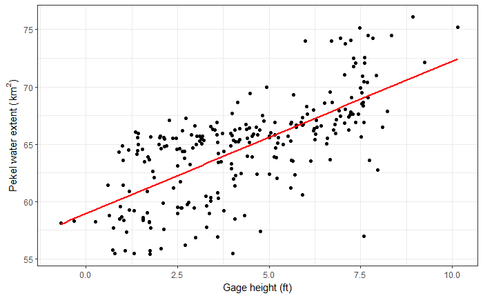

Replace missing Pekel data water values with the equation

$y = 58.9383998 + 1.3310656x_i$

Normalize the values to zero mean and unit variance for comparison.

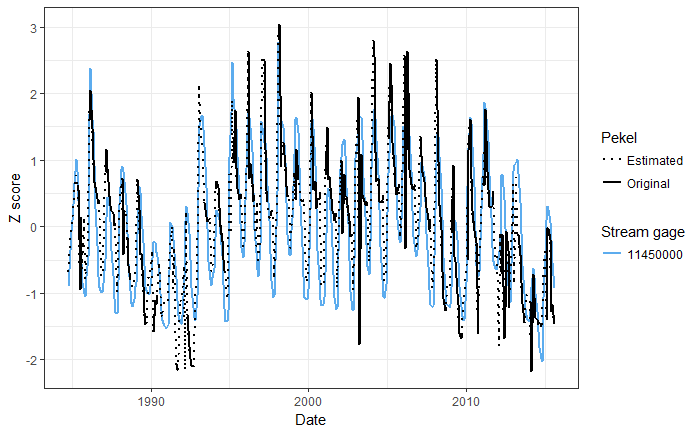